# Gaussian simulation using R/gstlearn - Correction

Option Géostatistique 2024

```r
knitr::opts_chunk$set(echo = TRUE)
rm(list=ls())

library(minigst)
```

#Preamble

```r
OptCst_defineByKey("ASP",0) # Fix the aspect ratio in all future plots
```

1. Create two `gstlearn` data bases:
- one named `dat` containing point observations of two variables across Scotland: the elevation (`Elevation`) and the temperature (`January_temp`),
- another named `target` containing a grid of points covering Scotland with a selection variable (`inshore`) selecting the points that are on land, and a variable (`Elevation`) giving the elevation at every point on land.

```r
## Data points
data("Scotland")
dat = dfToDb(Scotland,coordnames = c("Longitude","Latitude"))
#dat

## Target grid
data("ScotlandGrid")
target = dfToDbGrid(df=ScotlandGrid,coordnames=c("Longitude","Latitude"))
addSel(target,target["inshore"])
```

2. Our variable of interest is `January_temp`. Compute an omni-directional experimental variogram on the observations and fit a model on it.

```r
## Omni-directional experimental variogram
vario = vario_exp(dat, vname="January_temp", nlag=40, dlag=10.)
dev.new()
plot_vario(vario)

## Fit model
struct_names = c("NUGGET", "SPHERICAL", "CUBIC")
model = model_fit(vario,struct=struct_names, pruneModel = FALSE)
model$display()
```

[output not shown]

```r
dev.new()
plot_vario(vario, model)
```

# Unconditional simulation

Generate samples from the model fitted on the observations, simulating with a single turning band, then with 10 bands, then with 1000 bands. Plot the results.

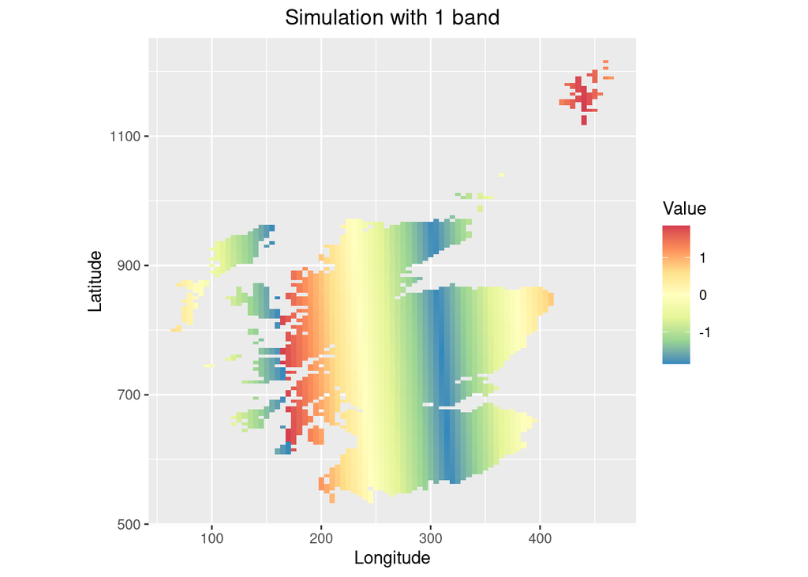

```r
# Simulations
minirgrf(target, model, 1, ntuba = 1, simname = "Sim1")
minirgrf(target, model, 1, ntuba = 10, simname = "Sim10")
minirgrf(target, model, 1, ntuba = 1000, simname = "Sim1000")

# Plots
dbplot_grid(db=target,color="Sim1", cmap = "Spectral", title = "Simulation with 1 band", legendTitle= "Value")
```

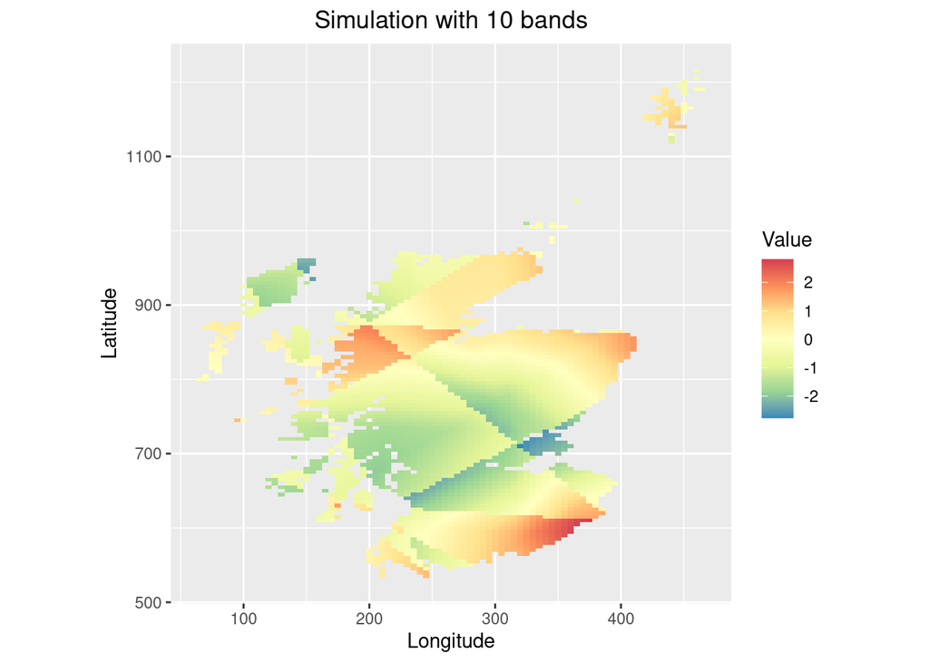

```r
dbplot_grid(db=target,color="Sim10", cmap = "Spectral", title = "Simulation with 10 bands", legendTitle= "Value")
```

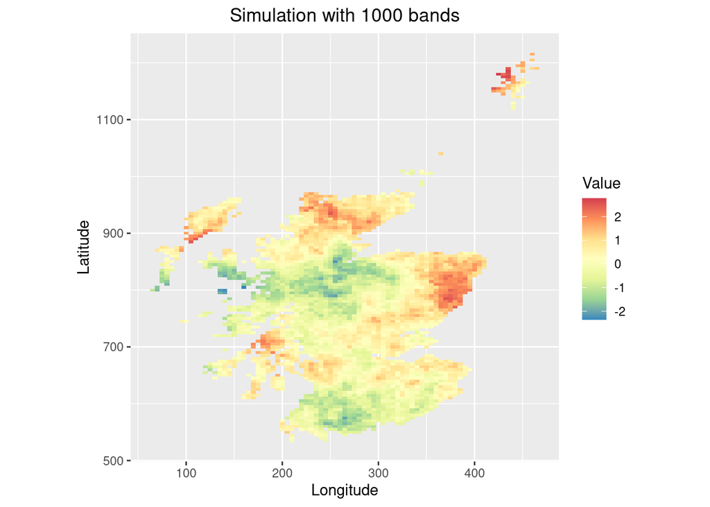

```r
dbplot_grid(db=target,color="Sim1000", cmap = "Spectral", title = "Simulation with 1000 bands", legendTitle= "Value")
```

# Conditional simulations

1. Check that the variable of interest `January_temp` can be reasonably assumed to have a gaussian distribution.

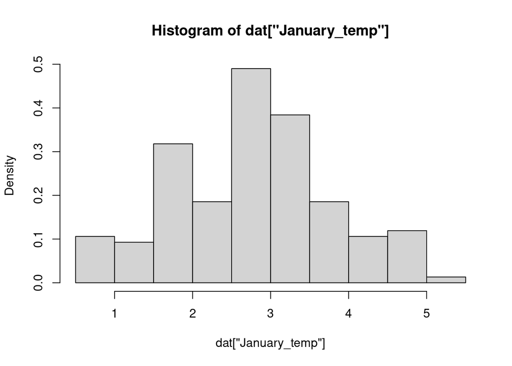

```r
hist(dat["January_temp"], freq = F)
```

2. Update the model so that its mean corresponds to the Kriging mean of the conditioning data.

```r
setMean(model, kriging_mean(dat,"January_temp",model))
```

3. Generate 10 conditional simulations using 1000 turning bands.

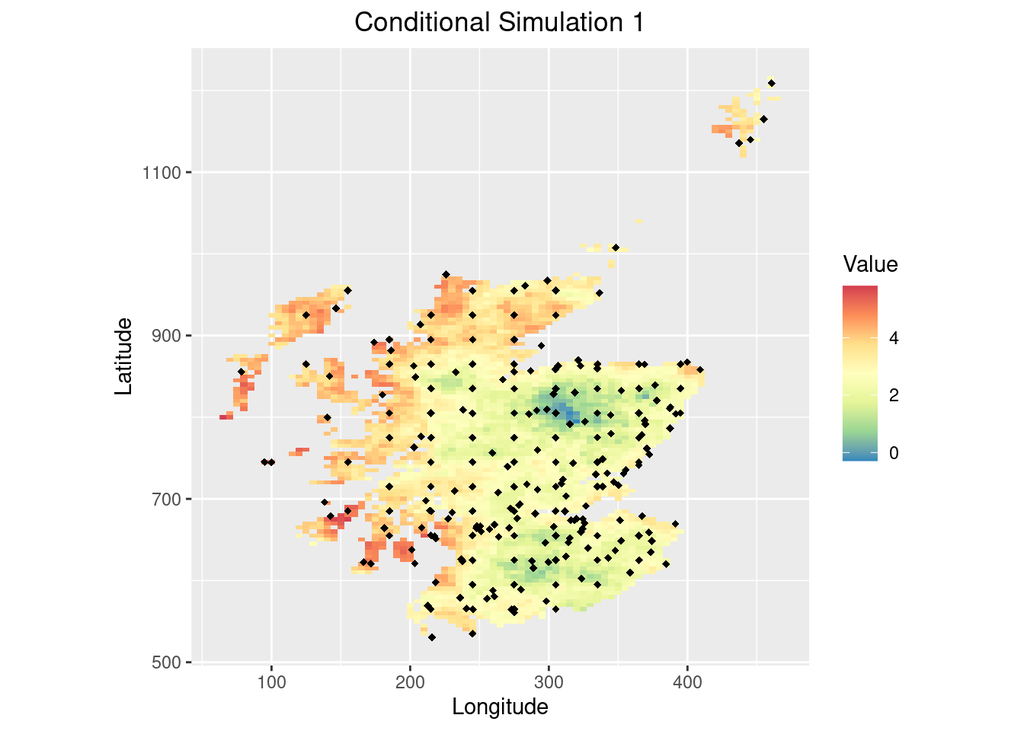

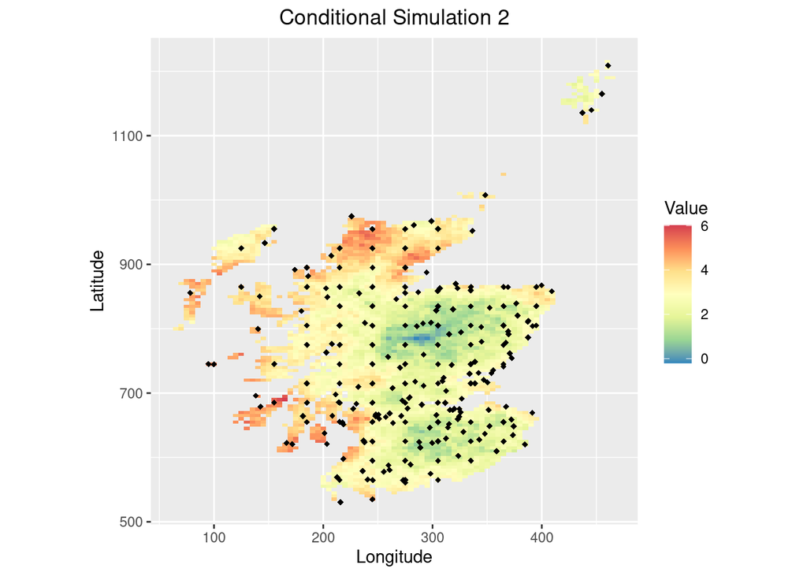

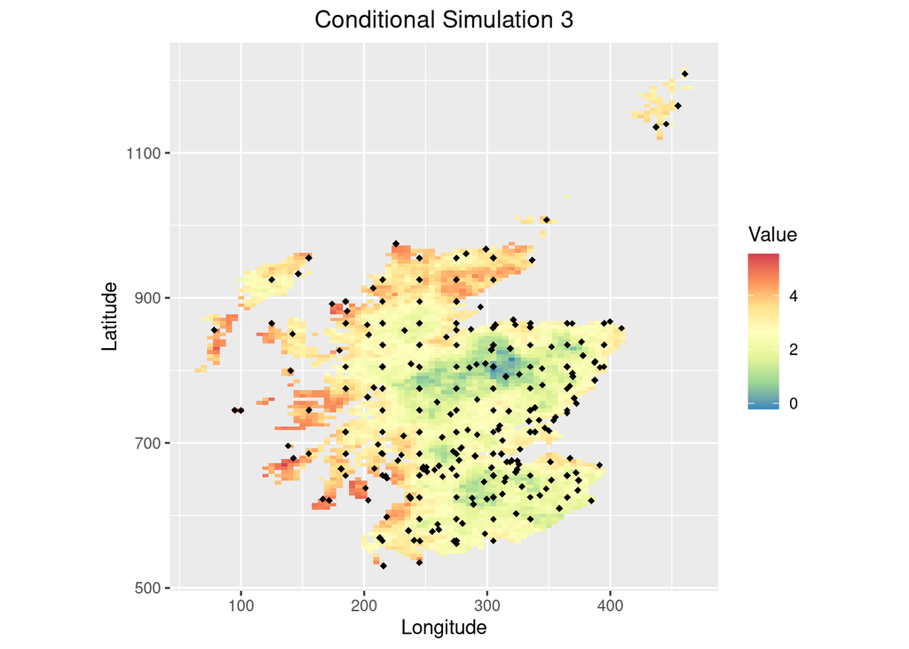

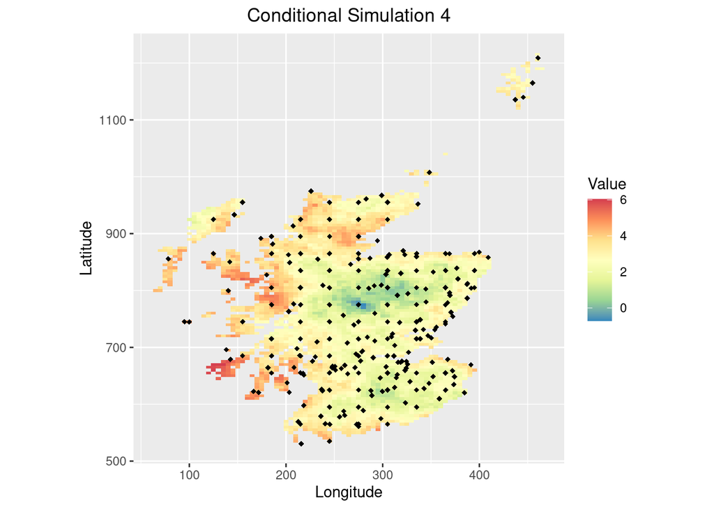

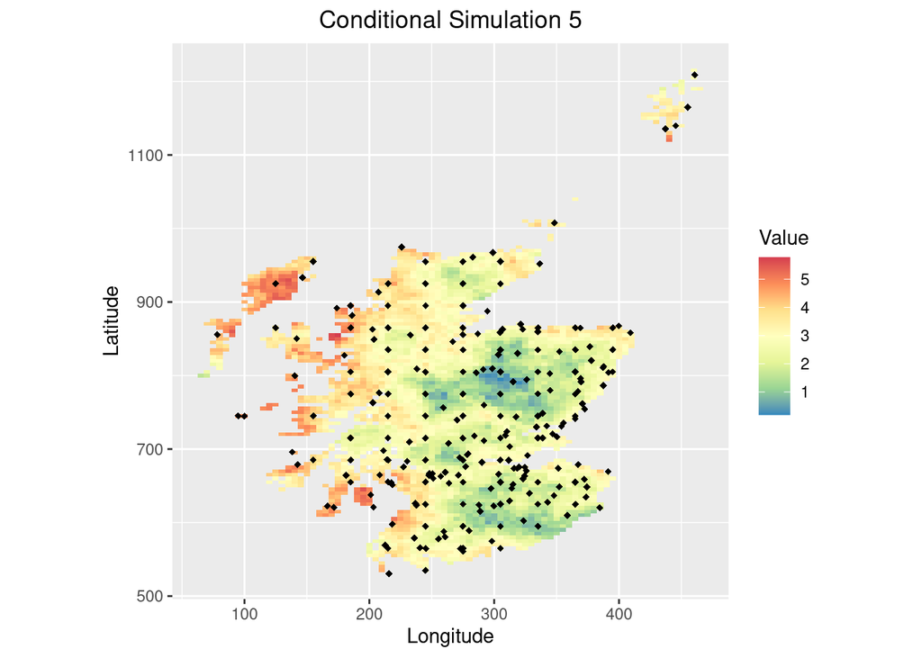

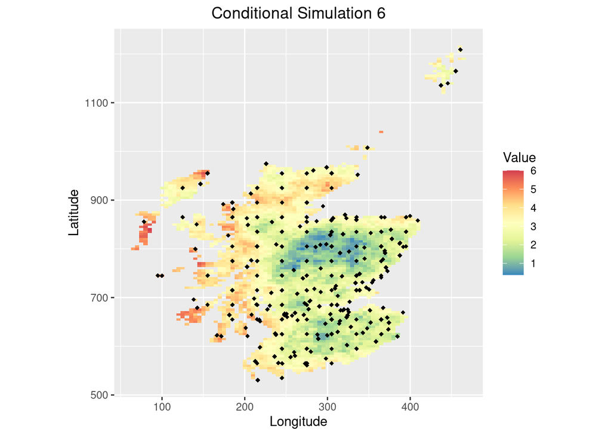

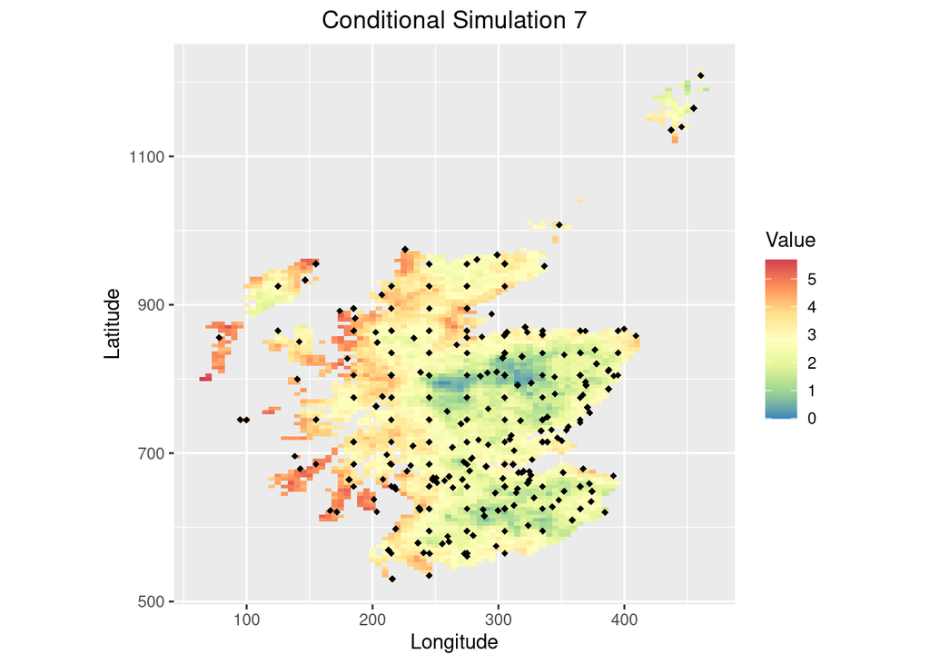

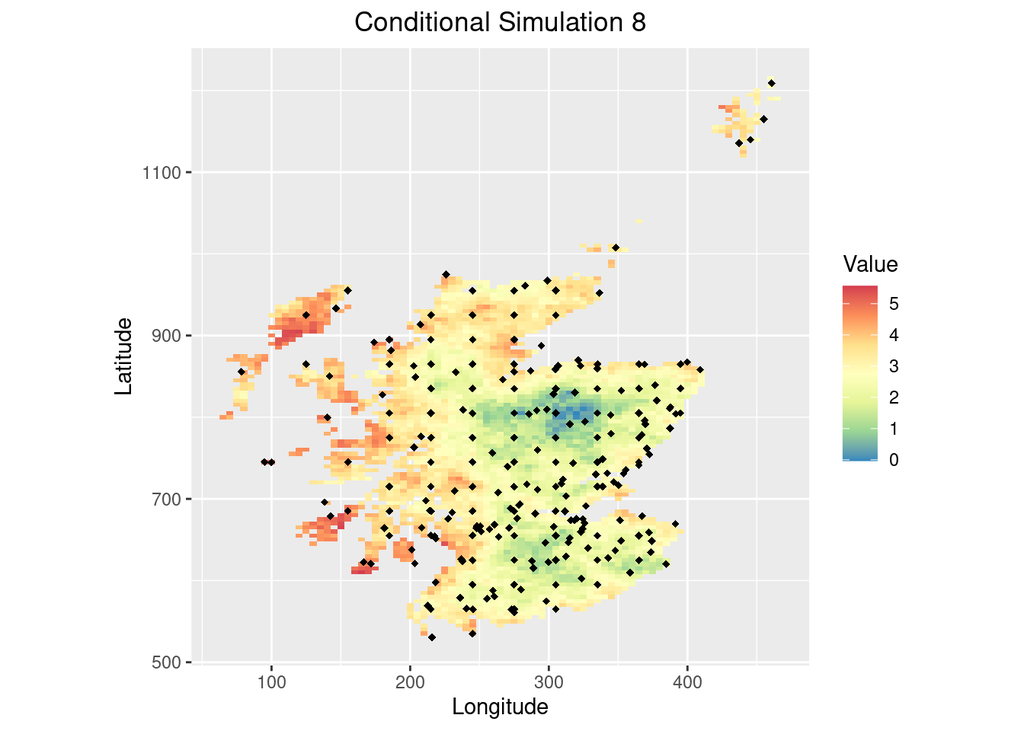

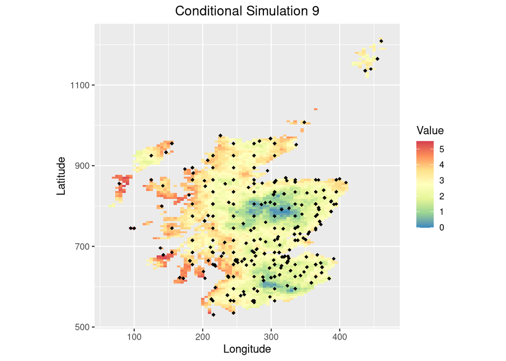

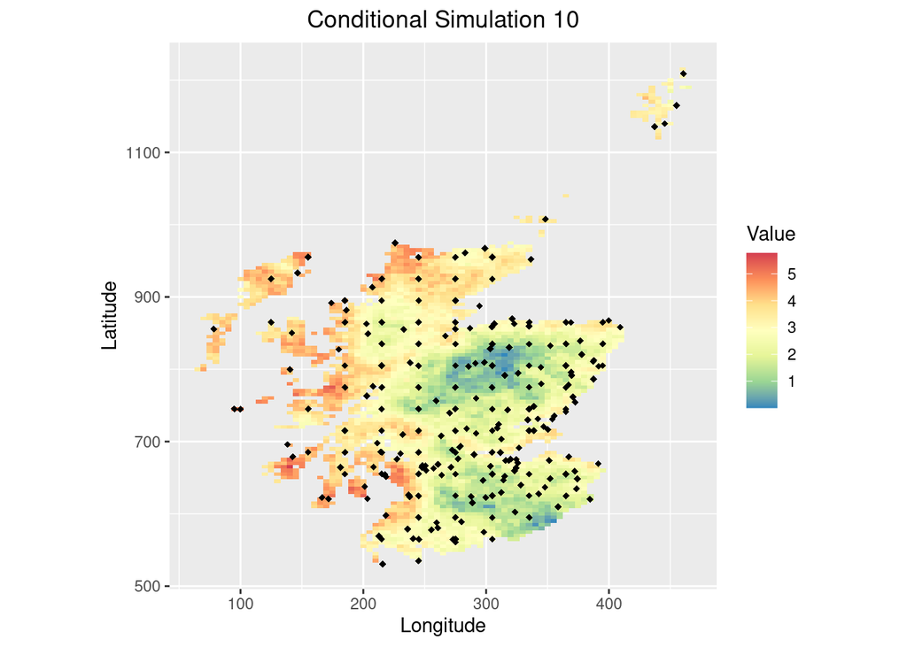

```r
# Simulations
minirgrf(target, model, nsim = 10, ntuba = 1000, dbcond = dat, vcond = "January_temp", seed = 13231)

# Plots
for (i in 1:10){
  p = dbplot_grid(db=target,color=paste0("Simu.January_temp.",i), cmap = "Spectral", legendTitle= "Value", title = paste0("Conditional Simulation ", i))
  p=addPoints(p,dat["x1"],dat["x2"], shape=18, size=1.5)
  print(p)
}
```

# Application : Probability of exceedence

1. Turn the simulation results into binary variables taking the value 1 if the simulated value is greater than 2 and 0 otherwise. Then, compute the probability of the temperature exceeding 2°C as the mean of these binary variables.

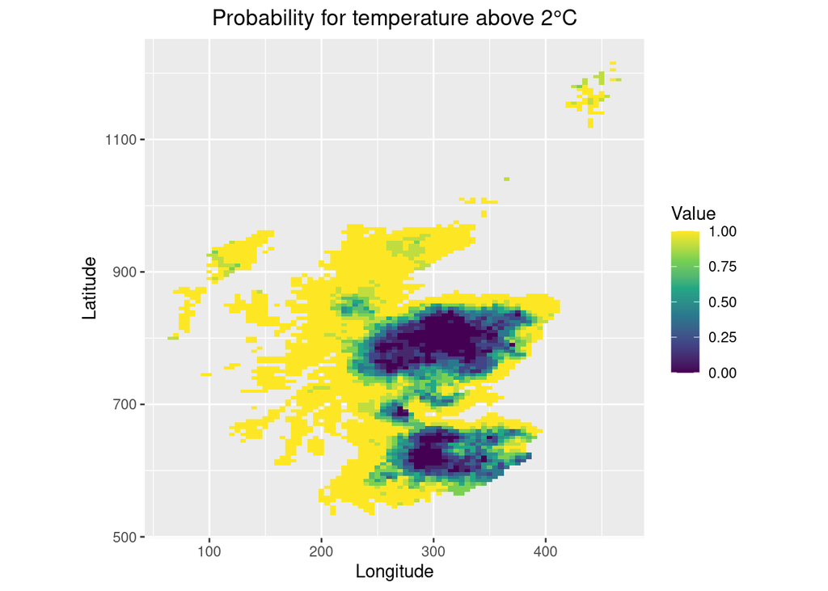

```r
## Turn simulation results into binary variable
binvar = target["Simu.January_temp*"] > 2

## Average binary variables
addVarToDb(target, apply(binvar,1,mean), "Prob")

# Plot the results
dbplot_grid(db=target,color="Prob", title = "Probability for temperature above 2°C", legendTitle= "Value")
```